# Seasonality Experiments

**What is the best way to represent seasonality for the jellyfish dataset?**

```r
source("../../setup.R")
suppressPackageStartupMessages({library(gridExtra)})

jec <- get_input_data("jelly_coper_all_revised.csv.gz")

jec <- jec |>
  mutate(presence = (ind_m2 > 0) |> factor(),
         vel = sqrt(uo^2 + vo^2),
         month = lubridate::month(date) |> factor(levels = 1:12),
         day_of_year = lubridate::yday(date))

head(jec)
```

```
## # A tibble: 6 × 23
##   date       depth ind_m2 bathy_depth   chl    no3  nppv    o2   po4    si   lon
##   <date>     <dbl>  <dbl>       <dbl> <dbl>  <dbl> <dbl> <dbl> <dbl> <dbl> <dbl>
## 1 1999-06-08   102   102.        99.1 0.151 0.0238  2.96  294. 0.352  2.18 -65.6
## 2 1999-06-08   270     0        252.  0.142 0.0229  2.88  289. 0.358  2.33 -66.5
## 3 1999-06-08    96   134.       109.  0.151 0.0243  2.99  290. 0.344  2.44 -66.1
## 4 1999-06-08    97  1491.        72.4 0.147 0.0238  2.94  291. 0.363  2.37 -66.4
## 5 1999-06-08   166     0        163.  0.133 0.0212  2.46  282. 0.243  1.77 -66.9
## 6 1999-06-08    62  1238.        93.1 0.144 0.0233  2.85  287. 0.317  2.40 -66.5
## # ℹ 12 more variables: lat <dbl>, bottomT <dbl>, mlotst <dbl>, so <dbl>,
## #   thetao <dbl>, uo <dbl>, vo <dbl>, zos <dbl>, presence <fct>, vel <dbl>,
## #   month <fct>, day_of_year <dbl>
```

# Options for Representation

## 1. Month as factor

Self-explanatory.

## 2. Day-of-year

Also self-explanatory.

## 3. Day length + derivative of day length

Day length can be calculated as a function of latitude and day of year. Derivative here is approximated as the difference between day length for one day and the next. Derivative is optional and omitted in some cases.

[Formula to approximate solar declination angle](https://www.pveducation.org/pvcdrom/properties-of-sunlight/declination-angle)

[Formula to approximate day length](https://www.researchgate.net/post/Geometrically_Derived_Formula_for_Day_Length_Based_on_Latitude_and_Time_of_Year)

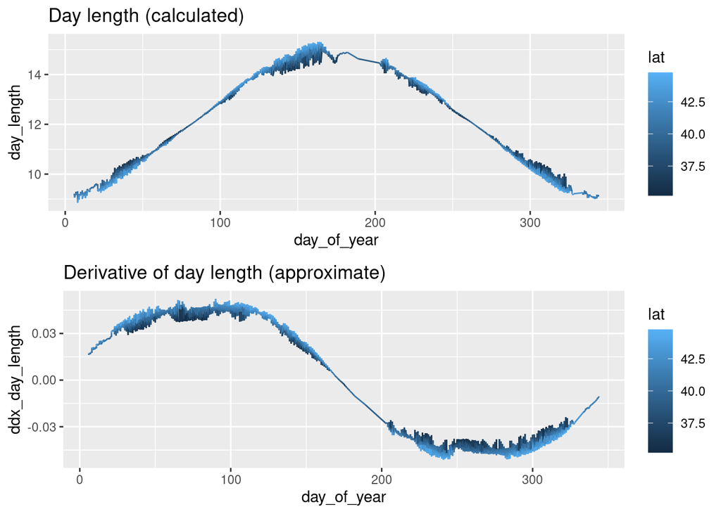

```r
#' Approximates solar declination angle, helper
get_soldecang <- function(day_of_year) {
  -23.45 * cos((360 / 365) * (day_of_year + 10) * pi/180)
}

#' Approximates length of day
get_daylength <- function(day_of_year, latitude) {
  24/pi * acos(-tan(latitude * pi/180) * tan(get_soldecang(day_of_year) * pi/180))
}

#' Approximates derivative of length of day
get_ddx_daylength <- function(day_of_year, latitude) {
  p1 <- get_daylength(day_of_year, latitude)
  p2 <- get_daylength(day_of_year + 1, latitude)
  return(p2-p1)
}

jec <- jec |>
  mutate(day_length = get_daylength(day_of_year, lat),
         ddx_day_length = get_ddx_daylength(day_of_year, lat))

grid.arrange(
  ggplot(jec, aes(x = day_of_year, col = lat, y = day_length)) + geom_line() +
    ggtitle("Day length (calculated)"),
  ggplot(jec, aes(x = day_of_year, col = lat, y = ddx_day_length)) + geom_line() +
    ggtitle("Derivative of day length (approximate)"))
```

## 4. Rolling seasonality

Having variables representing the percentage of each season relative to the centrepoints of summer, spring, fall, winter. sharper curves than sin/cosine relationships are less realistic to real conditions

This involves some approximates as the exact dates of equinoxes do vary by a day or two year-by-year

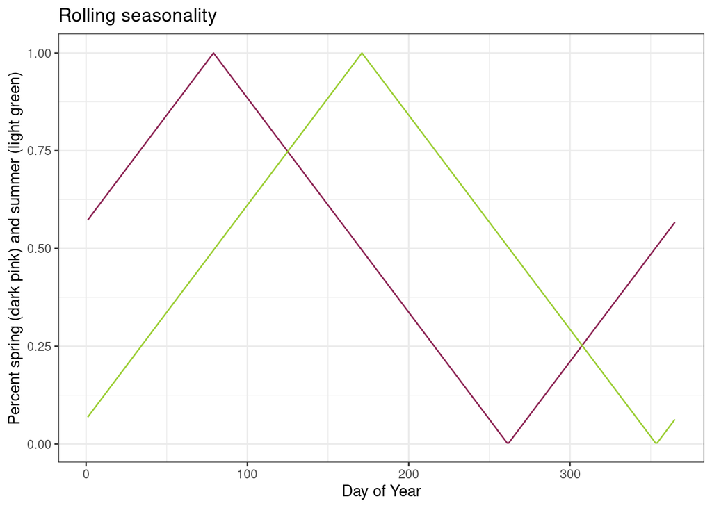

```r
season_axes <- list(spring = 79, # Mar 20
                    summer = 171, # Jun 20
                    fall = 265, # Sep 22
                    winter = 355) # Dec 21

# Calculates how close a date is to a reference date as a percentage
# 1 represents the same date, 0 represents half a year away
percent_month <- function(day_of_year, reference) {
  1 - pmin(
    abs(reference - day_of_year),
    365 - abs(reference - day_of_year)
  )/365*2
}

# omitting fall and winter since fall = 1 - spring, winter = 1 - summer
rolling_cols <- season_axes[c("spring", "summer")] |>
  lapply(function(x) percent_month(jec$day_of_year, x)) |>
  bind_cols() |>
  rename(percent_spring = spring, percent_summer = summer)

jec <- bind_cols(jec, rolling_cols)

# Plot
season_axes[c("spring", "summer")] |>
  lapply(function(x) percent_month(1:365, x)) |>
  bind_cols() |>
  mutate(x = 1:365) |>
  ggplot(aes(x = x)) +
    geom_line(aes(y = spring), col = "violetred4") +
    geom_line(aes(y = summer), col = "yellowgreen") +
  theme_bw() +
  labs(x = "Day of Year", y = "Percent spring (dark pink) and summer (light green)",
       title = "Rolling seasonality")
```

## 5. Height and Direction of the sun

Using the [`suncalc`](https://www.rdocumentation.org/packages/suncalc/versions/0.5.1) package to calculate height and azimuth based on date/lat/lon

There is less of an obvious distinction between spring and fall in this case

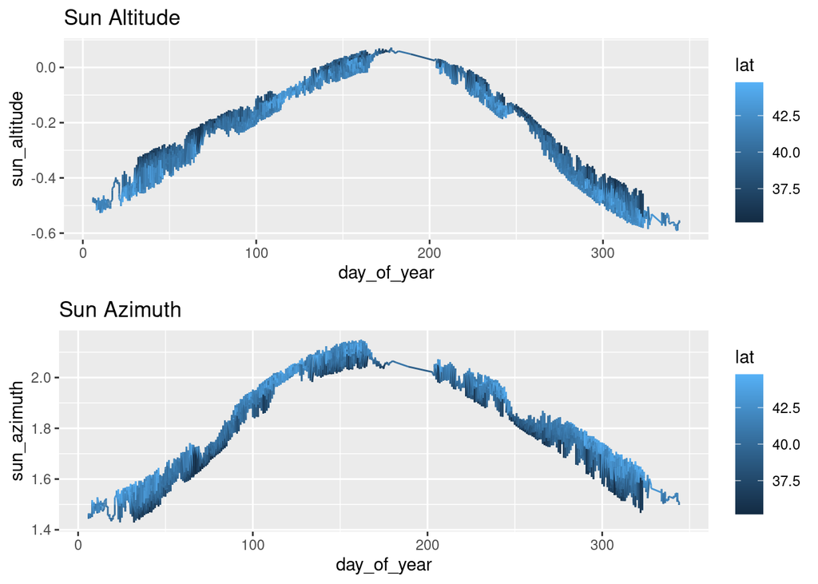

```r
suppressPackageStartupMessages({library(suncalc)})

jec <- jec |>
  bind_cols(suncalc::getSunlightPosition(data = jec) |>
    select(sun_altitude = altitude, sun_azimuth = azimuth))

grid.arrange(
  ggplot(jec, aes(x = day_of_year, col = lat, y = sun_altitude)) + geom_line() +
    ggtitle("Sun Altitude"),
  ggplot(jec, aes(x = day_of_year, col = lat, y = sun_azimuth)) + geom_line() +
    ggtitle("Sun Azimuth"))
```

# Comparing

Ok, we have 5 options for how to represent seasonality. How do they compare??

```r
jec_split <- initial_split(jec, prop = .75, strata = presence)
folds <- vfold_cv(training(jec_split), v = 5, repeats = 1, strata = presence)

# Creating recipes with each set of possible time variables
seasonality_options <- list(
  "month_factor" = c("month"),
  "day_of_year" = c("day_of_year"),
  "day_length_ddx" = c("day_length", "ddx_day_length"),
  "rolling" = c("percent_spring", "percent_summer"),
  "sun_position" = c("sun_altitude", "sun_azimuth"),
  "day_length" = c("day_length")
)

id_variables_base <-
  c("date", "ind_m2", "depth", "lon", "lat", "uo", "vo", "month",
    "day_of_year", "day_length", "ddx_day_length", "percent_spring",
    "percent_summer", "sun_altitude", "sun_azimuth")

# Helper - creates a recipe using a specific set of seasonality variables
create_recipe_variant <- function(seasonality_vars) {
  id_vars <- id_variables_base[!(id_variables_base %in% seasonality_vars)]

  recipe(presence ~ .,
         data = training(jec_split)) |>
  update_role(all_of(id_vars), new_role = "id") |> # Critical line
  step_log(bathy_depth, offset = 1, base = 10) |>
  step_normalize(all_numeric_predictors()) |>
  step_dummy(all_nominal_predictors())
}

recipe_list <- seasonality_options |>
  lapply(create_recipe_variant)

model_spec <- boost_tree() |>
  set_mode("classification") |>
  set_engine("xgboost") |>
  set_args(trees = 500,
           learn_rate = .1,
           tree_depth = 4,
           mtry = 5,
           min_n = 10)

time_workflows <- workflow_set(recipe_list, list(model_spec), cross = TRUE)

# Fitting all workflows & collecting metrics
wkfs_results <- time_workflows |>
  workflow_map(fn = "fit_resamples", # method to apply in quotes
               verbose = FALSE,
               seed = 400,
               resamples = folds, # arguments for fn
               metrics =  metric_set(roc_auc, sens, spec, accuracy),
               control = control_resamples(save_pred = TRUE, save_workflow = TRUE))
```

```r
wkfs_results |>
  rank_results(rank_metric = "roc_auc")
```

```
## # A tibble: 24 × 9
##    wflow_id         .config .metric  mean std_err     n preprocessor model  rank
##    <chr>            <chr>   <chr>   <dbl>   <dbl> <int> <chr>        <chr> <int>
##  1 rolling_boost_t… Prepro… accura… 0.752 0.00194     5 recipe       boos…     1
##  2 rolling_boost_t… Prepro… roc_auc 0.777 0.00392     5 recipe       boos…     1
##  3 rolling_boost_t… Prepro… sens    0.892 0.00415     5 recipe       boos…     1
##  4 rolling_boost_t… Prepro… spec    0.436 0.0110      5 recipe       boos…     1
##  5 day_length_ddx_… Prepro… accura… 0.755 0.00302     5 recipe       boos…     2
##  6 day_length_ddx_… Prepro… roc_auc 0.776 0.00480     5 recipe       boos…     2
##  7 day_length_ddx_… Prepro… sens    0.895 0.00337     5 recipe       boos…     2
##  8 day_length_ddx_… Prepro… spec    0.440 0.0132      5 recipe       boos…     2
##  9 sun_position_bo… Prepro… accura… 0.750 0.00160     5 recipe       boos…     3
## 10 sun_position_bo… Prepro… roc_auc 0.776 0.00495     5 recipe       boos…     3
## # ℹ 14 more rows
```

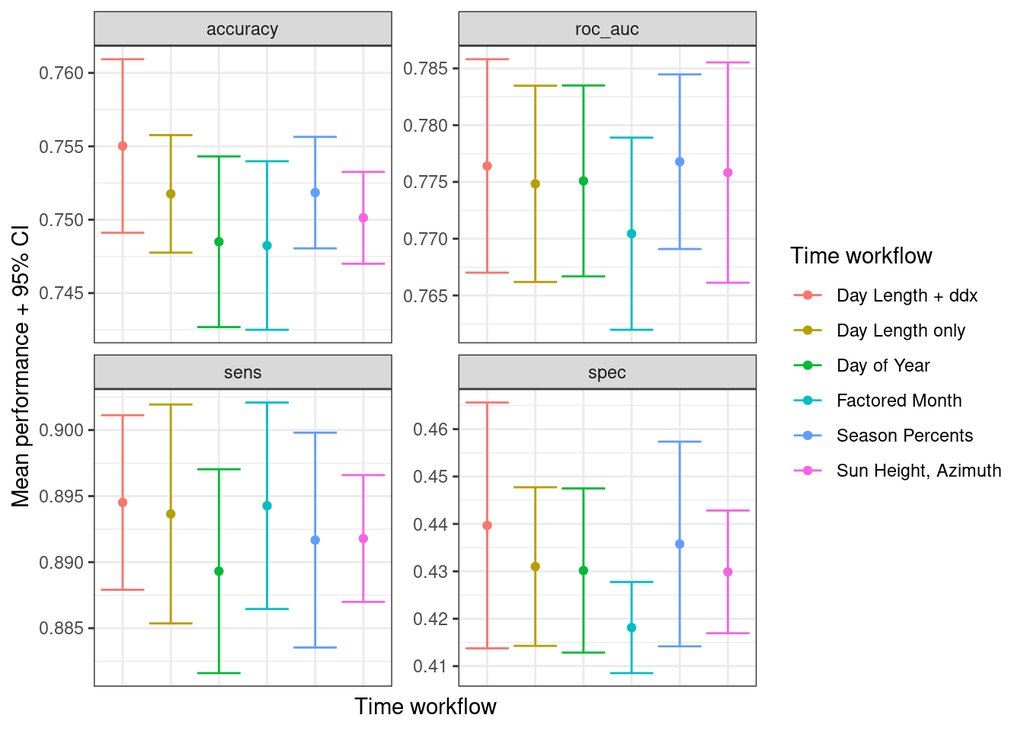

```r
better_titles <- list(
  "day_length_ddx_boost_tree" = "Day Length + ddx",
  "day_of_year_boost_tree" = "Day of Year",
  "month_factor_boost_tree" = "Factored Month",
  "rolling_boost_tree" = "Season Percents",
  "sun_position_boost_tree" = "Sun Height, Azimuth",
  "day_length_boost_tree" = "Day Length only"
)

wkfs_results |>
  rank_results(rank_metric = "roc_auc") |>
  ggplot(aes(x = better_titles[wflow_id] |> unlist(),
             y = mean,
             col = better_titles[wflow_id] |> unlist())) +
  facet_wrap(~.metric, scales = "free_y") +
  geom_point() +
  geom_errorbar(aes(
    ymin = mean - std_err * 1.96,
    ymax = mean + std_err * 1.96
  )) +
  theme_bw() +
  theme(axis.text.x = element_blank(),
        axis.ticks.x = element_blank()) +
  labs(x = "Time workflow", y = "Mean performance + 95% CI", col = "Time workflow")
```